# R Notebook midterm: 419 Survey of Multivariate Methods

# Setup

### source setup

```r
source("setup-owell.R");
```

[output not shown]

### o well

```r
# options(digits = 4); # limit the matrix form
str(wells.df);
```

```
## 'data.frame':    23 obs. of  59 variables:
##  $ well                : int  1 2 3 4 5 6 7 8 9 10 ...
##  $ latitude            : num  28.6 28.6 28.6 28.6 28.6 ...
##  $ longitude           : num  34.8 34.8 34.8 34.9 35 ...
##  $ altitude.ft         : int  257 1652 924 1815 1408 2640 956 1312 595 2291 ...
##  $ sea.m               : int  1000 2000 5500 8000 19000 19000 17000 2000 3500 11000 ...
##  $ fault.m             : int  1200 400 400 1500 400 1500 1000 1100 1600 1100 ...
##  $ geology             : chr  "Sand" "Sand, Alkaline, Granite" "Alkaline, Conglomerate" "Alkaline" ...
##  $ geology.alkaline    : num  0 1 1 1 0 0 0 1 0 0 ...
##  $ geology.conglomerate: num  0 0 1 0 0 0 0 0 0 0 ...
##  $ geology.granite     : num  0 1 0 0 1 0 0 0 0 0 ...
##  $ geology.gypsum      : num  0 0 0 0 0 0 1 0 1 0 ...
##  $ geology.sand        : num  1 1 0 0 0 0 0 0 0 0 ...
##  $ geology.volcanic    : num  0 0 0 0 1 1 0 0 0 1 ...
##  $ As                  : num  0.2 0.3 0.7 0.2 0.7 0.3 0.3 0.6 0.2 0.1 ...
```

[output cut: 45 more lines]

### Default Group

```r
wells.df$Group = c(rep(1, 17), rep(2, 5), 3);
```

### = WSU COLORS =

```r
# https://brand.wsu.edu/visual/colors/
wsu.crimson = "#981e32";
wsu.gray    = "#717171";
```

# TESTING PROCEDURE

This midterm exam (Rnotebook-midterm) is a learning opportunity to review the content presented **and** to assess “weekly mini-tasks”. The total points available for this “learning opportunity” is between 150-200 points as detailed in each section below. For each question, review how much the item is worth in terms of points and plan your time wisely.

I would deem it “unwise” to spend hours on a question that is only worth 5 points.

Be certain to continue to document your “work hours” in your notebook. Especailly this week as you work on the midterm.

## Static/Existing Resources Are Allowed

This is an open-book examination. You can use your course notebooks (digital and old-school). You can use Internet resources (stackoverflow, Wikipedia, and Youtube).

## Dynamic/Living Resources Are _ **NOT**_ Allowed

**You cannot use a living resource on the exam.** That would include a classmate, student, sibling, parent, a tutor, online forums (where you ask the question after the exam period has begun).

## Questions?

If you have questions that need clarifying, please **privately chat with instructor (rocket.chat)**. Office hours will be held at normal times (and during normally scheduled class time as this is a **takehome** exam). The instructor will help you with any technical difficulties associated with getting the notebook to function.

## Deliverable

You should move the “midterm” folder to your local workspace. Once completed, you should move this folder into your Dropbox “deliverable” folder.

## Deadline

The midterm should be submitted in your Dropbox account before midnight (Sunday March 3/21, vernal equinox?)

## Levels of Mastery

- Do You **Remember**?
- Do You **Understand**?
- Can You **Apply** what you remember/understand to another similar problem?
- Can You **Analyze** and **Synthesize** Data?
- Can You **Evaluate** your analyses?
- Can You **Create** meaningful visualizations and summaries?

## Rubric of Mastery

For every 10 points, this is the general breakdown.

| Emerging | Developing | Mastering |
| --- | --- | --- |
| 0-4 | 5-7 | 8 - 10 |

# COURSE EXPECTATIONS (e.g., the “syllabus”)

## Instructor’s objective (10 points)

Describe how the instructor has designed this course. Be certain to include a statement of his primary objective, summarize sub-objectives, communicate how this design is “similar to” other courses you have taken at university, and communicate how it is “different from” other courses you have taken at university.

[output not shown]

[This is worth 10 points. Length of the response should demonstrate your understanding of mastery. Too verbose is better than too succinct and references to “lecture” concepts or examples is a demonstration of mastery.]

## Proportion of Statistical Methods (10 points)

Statistics is defined as “the discipline that concerns the collection, organization, analysis, interpretation and presentation of data.” (See https://en.wikipedia.org/wiki/Statistics)

Are each of these five factors equally weighted? Should they be?

### What is traditionally taught at university

Below, change the value of `x` to represent how you perceive “statistics” is generally taught at university based on these 5 factors: “collection”, “organization”, “analysis”, “interpretation”, “presentation”.

That is, what proportion of time is spent teaching about “data collection”? What proportion of time is spent teaching about “data organization” (cleanup)? And so on.

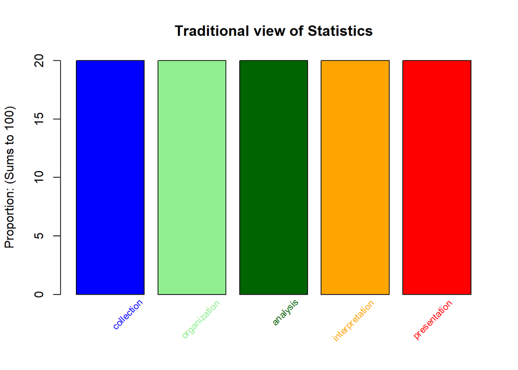

```r
x = c(20,20,20,20,20);


x.labels = c("collection", "organization", "analysis", "interpretation", "presentation");
x.colors = c("blue", "lightgreen", "darkgreen", "orange", "red");

barplot(x,
        col = x.colors,
        ylim = c(0, 20),
        ylab = "Proportion: (Sums to 100)",
        main="Traditional view of Statistics");


text(1.14* (1:5), par("usr")[3], col = x.colors, labels = x.labels, srt = 45, adj = c(1.1,1.1), xpd = TRUE, cex=.75);
```

### How the instructor perceives statistics

Below, change the value of `x` to represent how your INSTRUCTOR is trying to teach statistics (in this multivariate course) based on these 5 factors: “collection”, “organization”, “analysis”, “interpretation”, “presentation”.

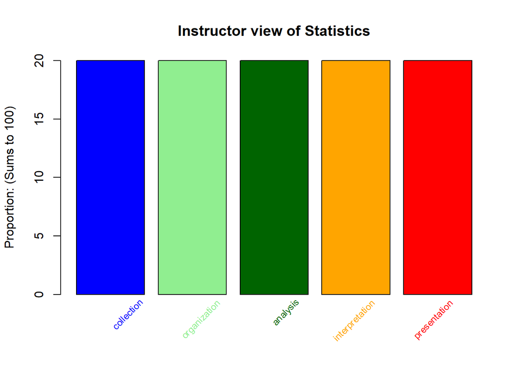

```r
x = c(20,20,20,20,20);


x.labels = c("collection", "organization", "analysis", "interpretation", "presentation");
x.colors = c("blue", "lightgreen", "darkgreen", "orange", "red");

barplot(x,
        col = x.colors,
        ylim = c(0, 20),
        ylab = "Proportion: (Sums to 100)",
        main="Instructor view of Statistics");


text(1.14* (1:5), par("usr")[3], col = x.colors, labels = x.labels, srt = 45, adj = c(1.1,1.1), xpd = TRUE, cex=.75);
```

### How you perceive statistics

Below, change the value of `x` to represent how you perceive “statistics” based on these 5 factors: “collection”, “organization”, “analysis”, “interpretation”, “presentation”.

What proportion of the time should be devoted to teaching you about “data collection”? And so on.

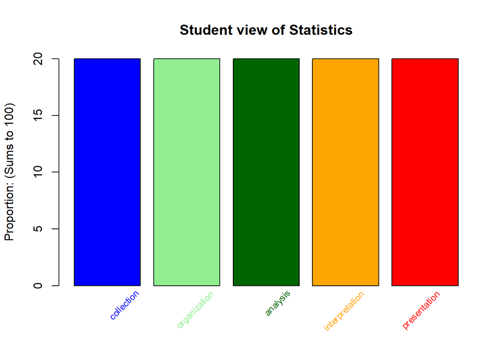

[output not shown]

```r
x = c(20,20,20,20,20);


x.labels = c("collection", "organization", "analysis", "interpretation", "presentation");
x.colors = c("blue", "lightgreen", "darkgreen", "orange", "red");

barplot(x,
        col = x.colors,
        ylim = c(0, 20),
        ylab = "Proportion: (Sums to 100)",
        main="Student view of Statistics");


text(1.14* (1:5), par("usr")[3], col = x.colors, labels = x.labels, srt = 45, adj = c(1.1,1.1), xpd = TRUE, cex=.75);
```

[The entire question is worth 10 points, including the 3 visualizations. Describe how you arrived at the proportions for each: university tradition, instructor protocol, your personal belief.]

## Learning Theory (10 points)

According to experts, learning is not a “hierarchy” but rather a “nonlinear” immersion of language: https://www.edweek.org/education/opinion-heres-whats-wrong-with-blooms-taxonomy-a-deeper-learning-perspective/2018/03 (PDF version is in “misc” folder of this “midterm”).

### Bloom Taxonomy

In the traditional Bloom model (see graphic referenced above), I would cluster the elements by pairing some learning elements:

- [High school] Knowledge/Comprehension: “what is the definition” and “what does it mean”
- [Early university] Application/Analysis: “how to apply the data” and “how to decompose the concept into subparts”
- [Seniors at university] Synthesis/Evaluation: “how to integrate subparts or concepts” and “how to evaluate” so you are prepared to create

As students in a senior-level course, my expectations are that you can refer to modern “textbook resources” (e.g., Brother Google, Stackoverflow, Wikipedia) and perform the “lower-ordered thinking” on your own.

### Learn by doing

In my estimation, the following quote reflects how learning works: ‘We remember 10% of what we “hear”, 50% of what we “see”, and 90% of what we “do”’. This is the foundation of an apprenticeship model.

Statistics is a language and I have chosen to immerse you in multivariate statistics by providing a “survey” of several key topics. Simultaneously, as the instructor I join in the “practice” to demonstrate how apprenticeship works. I provide you with a “411” on the needed tools I perceive important for you to succeed as a data analyst assessing multivariate data. Specifically, I have stated the following in the syllabus:

### Instructor Expectation

“The real (nonacademic) world moves fast, and I need to enable you to succeed there. My goal is to empower you, but that requires challenging you. Some of you may struggle with the intentional nonlinearity, vaguities (vagueness, YES, I made that word up), and other quirks you may find unsettling. The purpose is to empower you to become innovators and creators in a future I cannot predict.”

### Think about Thinking/Learning (Student Response)

Process the above information and write a response expressing your opinion about how learning works. You do not have to agree with the “expert opinion” expressed in the website/PDF. You do not have to agree with the instructor’s opinion. You do have to coherently “think about thinking” and articulate a response.

[output not shown]

[This is worth 10 points. Length of the response should demonstrate your understanding of mastery. Too verbose is better than too succinct and references to “lecture” concepts or examples is a demonstration of mastery.]

## Self-determination (10 points)

My five-year old recently shared the following while we were at Myrtle Beach over winter break picking up sea-shells: “Alex is the boss of Alex; daddy is the boss of daddy. Is that right?”

[Today is 3/14, as in 3.14159 2653589 7923284 626 … Alex has been taught this number in song firm at a very young age: https://www.youtube.com/watch?v=rKq4l5CiIOo]

Utilizing details specific to the Ryan/Deci explanation of self-determination theory and intrinsic motivation, respond to the statement of my son. Your response should demonstrate your understanding of the conversation as it relates to: (1) your natural-self personality, (2) the instructor’s natural-self personality, (3) each of your team-member’s natural-self personality.

[output not shown]

[This is worth 10 points. Length of the response should demonstrate your understanding of mastery. Too verbose is better than too succinct and references to “lecture” concepts or examples is a demonstration of mastery.]

# Central Tendencies

## Example 1

Below is a list of the first 32 prime numbers.

```r
x = pracma::primes(135);
length(x);
```

```
## [1] 32
```

```r
x;
```

```
##  [1]  2  3  5  7 11 13 17 19 23 29 31 37 41 43 47 53 59 61 67 71
##  [ reached getOption("max.print") -- omitted 12 entries ]
```

### mean

```r
mean(x);
```

```
## [1] 57.84375
```

### doMean

```r
doMean(x);
```

```
## [1] 59
```

### median

```r
median(x);
```

```
## [1] 56
```

### doMedian

```r
doMedian(x);
```

```
## [1] 53
```

### Student Response (5 points)

Based on “lecture”, what is the above output demonstrating? Of the two “central tendencies”, which would John Tukey prefer? Why would the instructor prefer the `doMean` over the `mean` and the `doMedian` over the `median`?

[output not shown]

[This is worth 5 points. Length of the response should demonstrate your understanding of mastery. Too verbose is better than too succinct and references to “lecture” concepts or examples is a demonstration of mastery.]